# DP_HW2

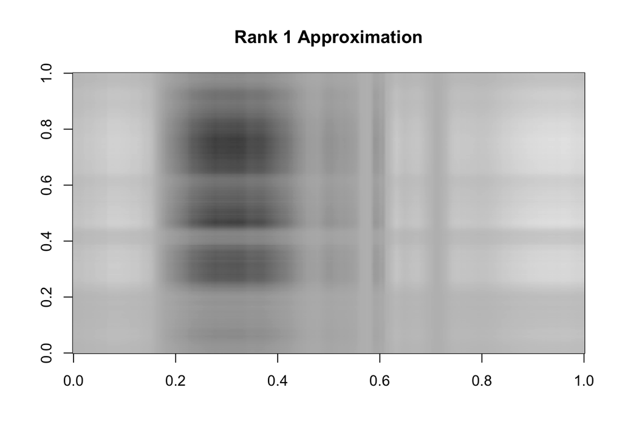

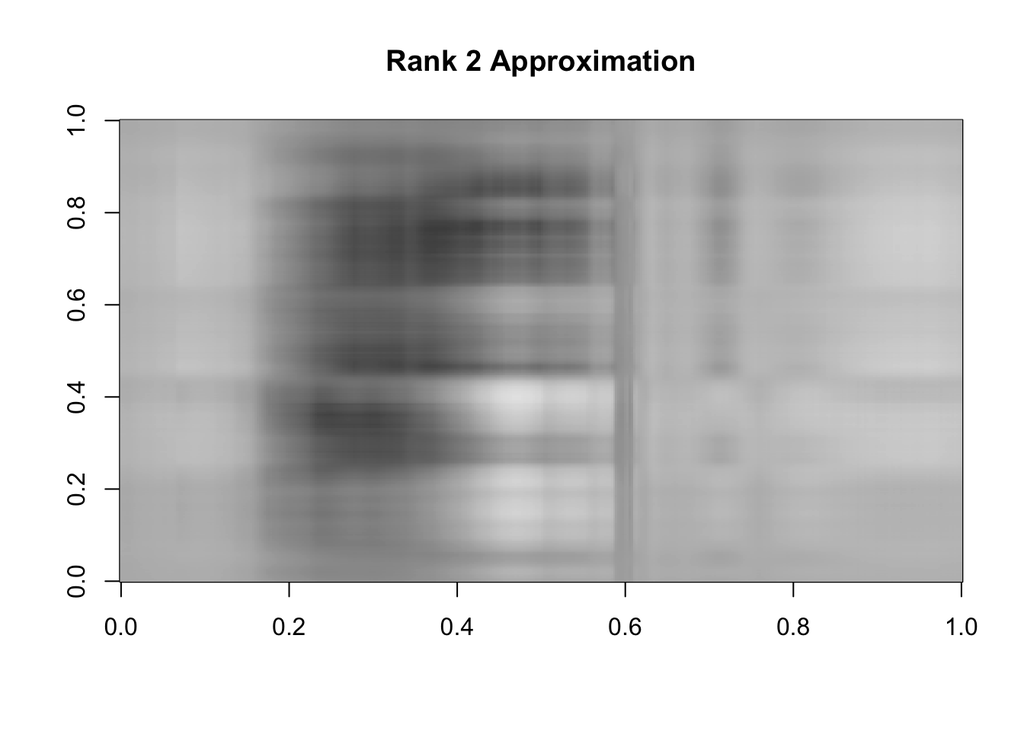

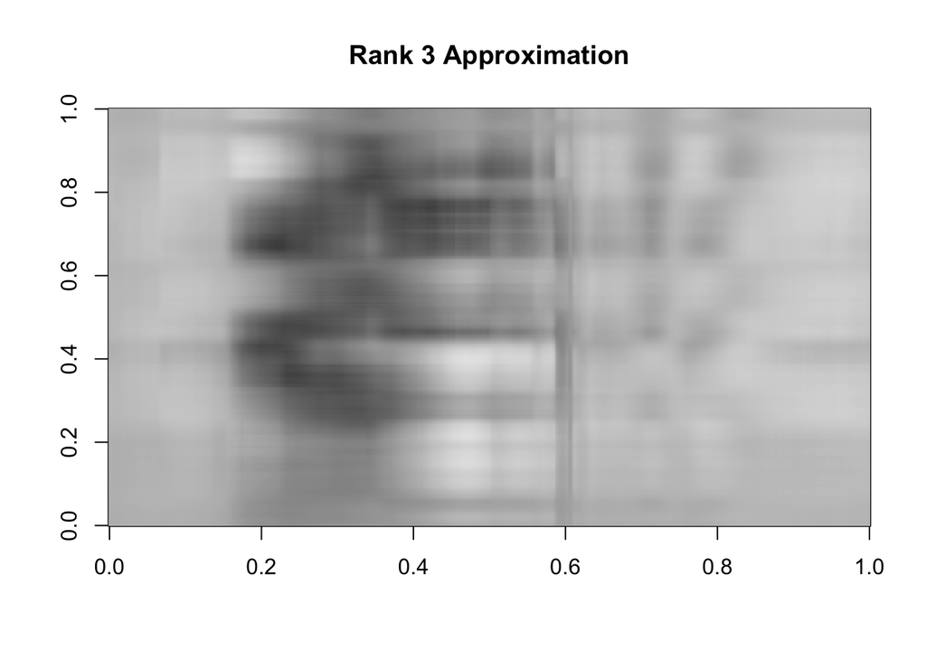

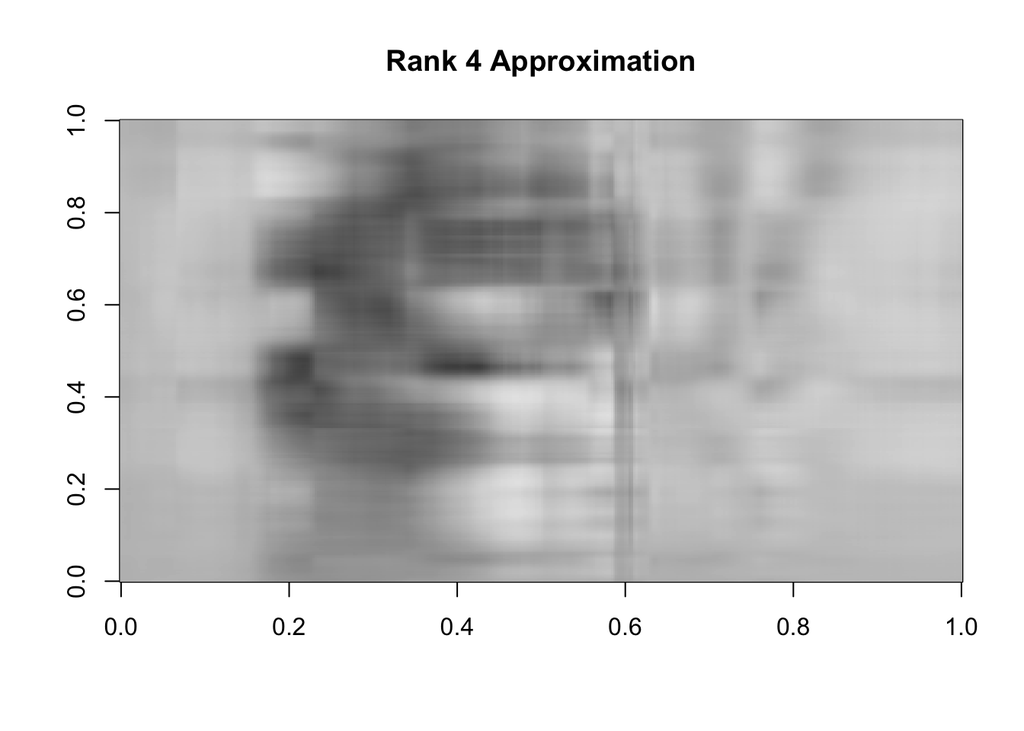

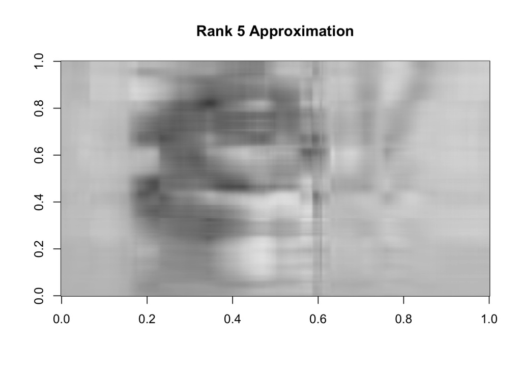

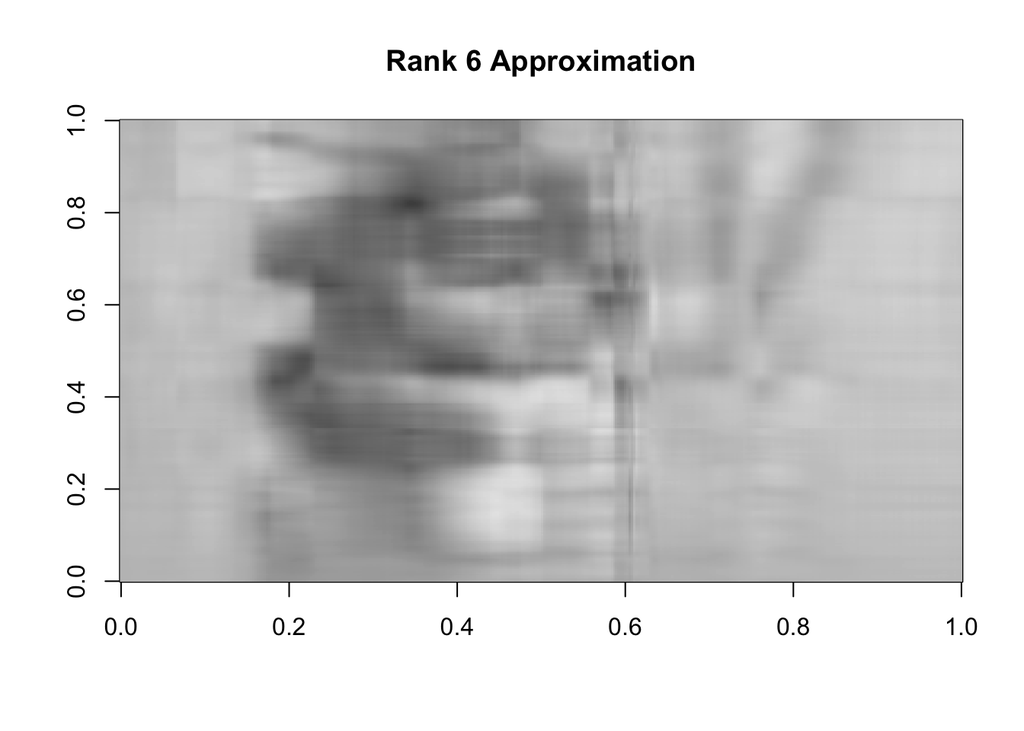

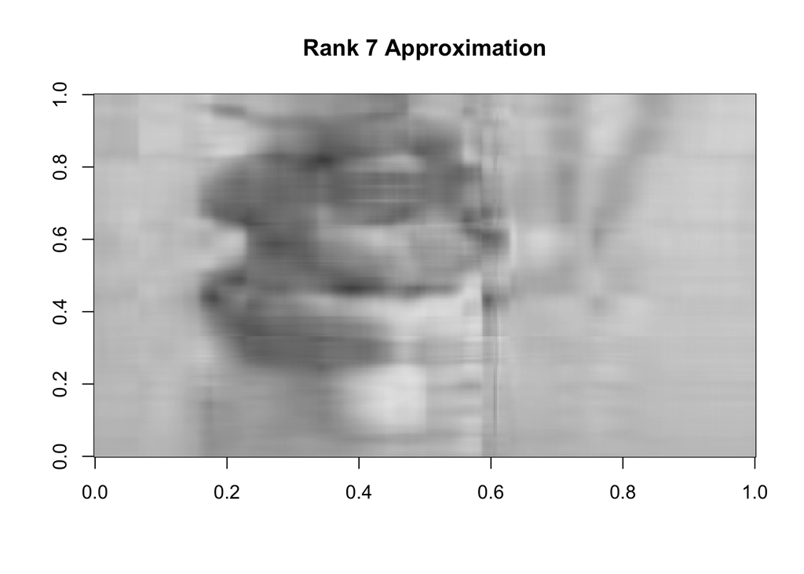

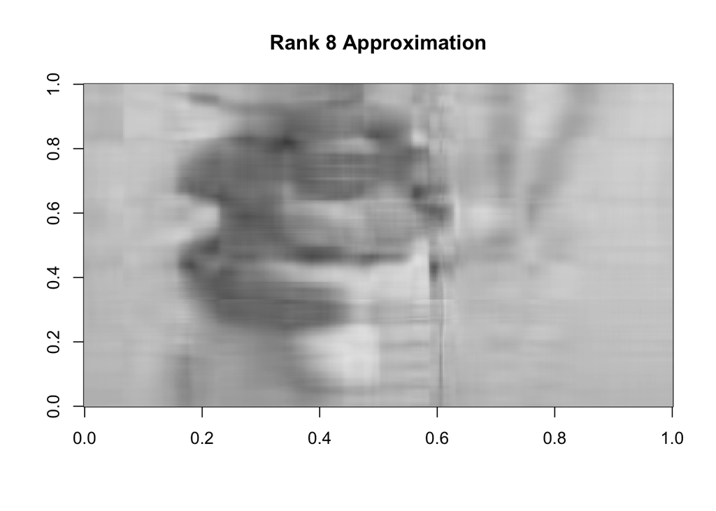

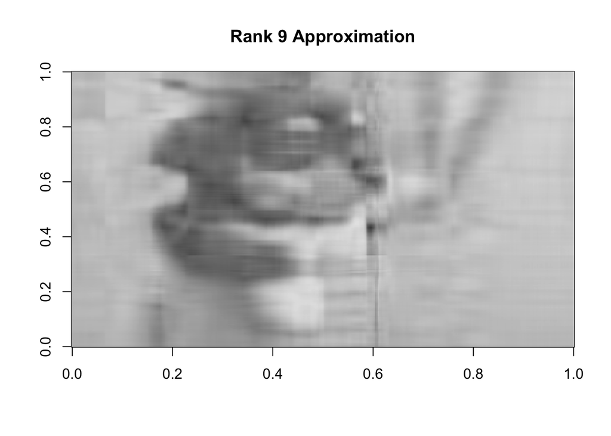

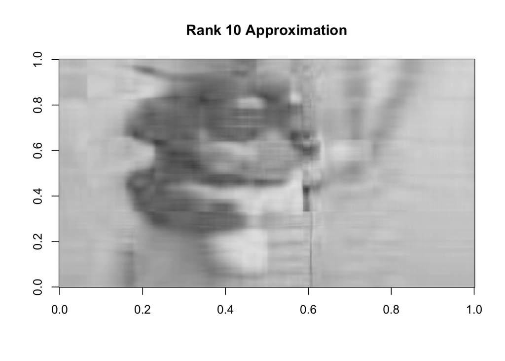

```r
for (k in 1:10) {
  result <- pca_rank_k_approx(x3, k)

  image(
    result$approx,
    col = gray.colors(256),
    main = paste("Rank", k, "Approximation")
  )
}
```

## image 3 - error plot

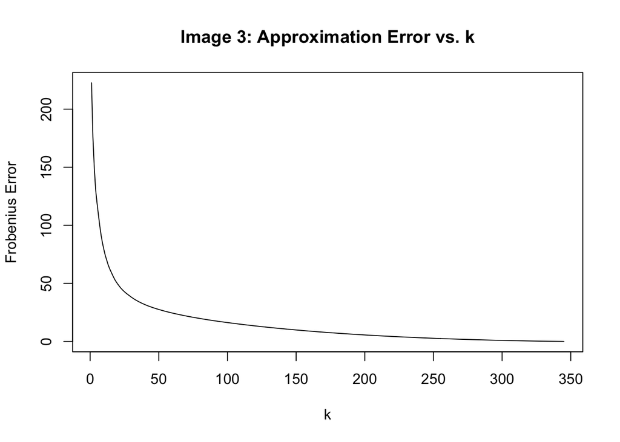

```r
p3 <- ncol(x3)
errors3 <- numeric(p3)

for (k in 1:p3) {
  result <- pca_rank_k_approx(x3, k)
  errors3[k] <- result$error
}

plot(
  1:p3,
  errors3,
  type = "l",
  xlab = "k",
  ylab = "Frobenius Error",
  main = "Image 3: Approximation Error vs. k"
)
```

## first eigenvector and PC score

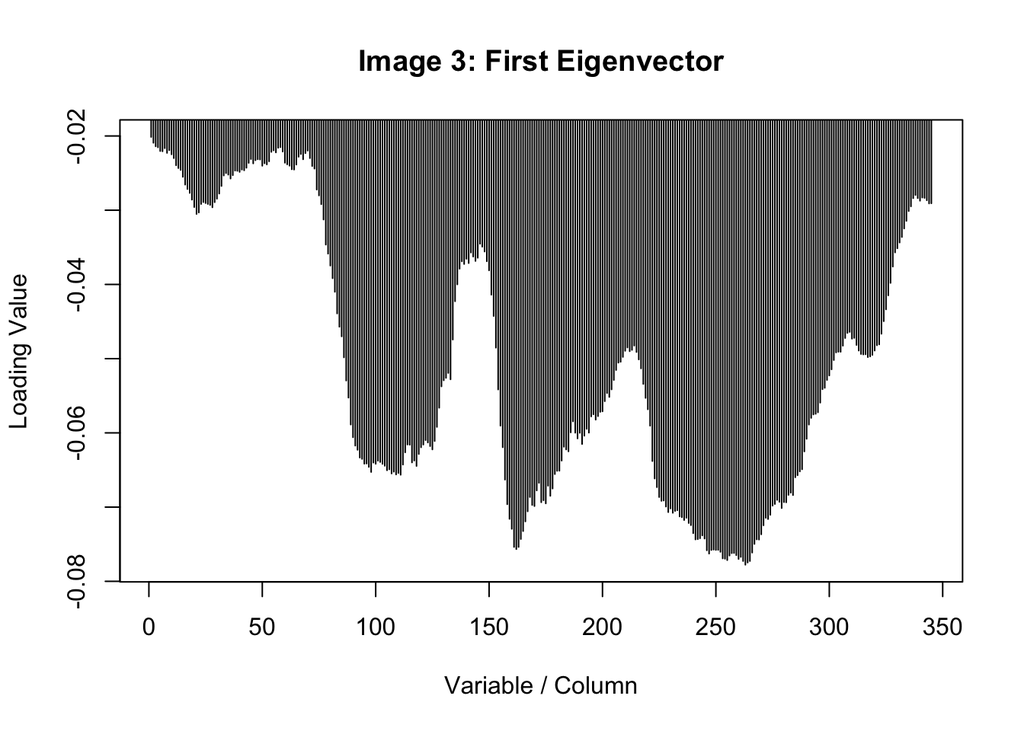

```r
pca3 <- prcomp(x3,
  center = FALSE,
  scale. = FALSE
)

u1_3 <- pca3$rotation[, 1]
z1_3 <- pca3$x[, 1]

plot(
  u1_3,
  type = "h",
  main = "Image 3: First Eigenvector",
  xlab = "Variable / Column",
  ylab = "Loading Value"
)
```

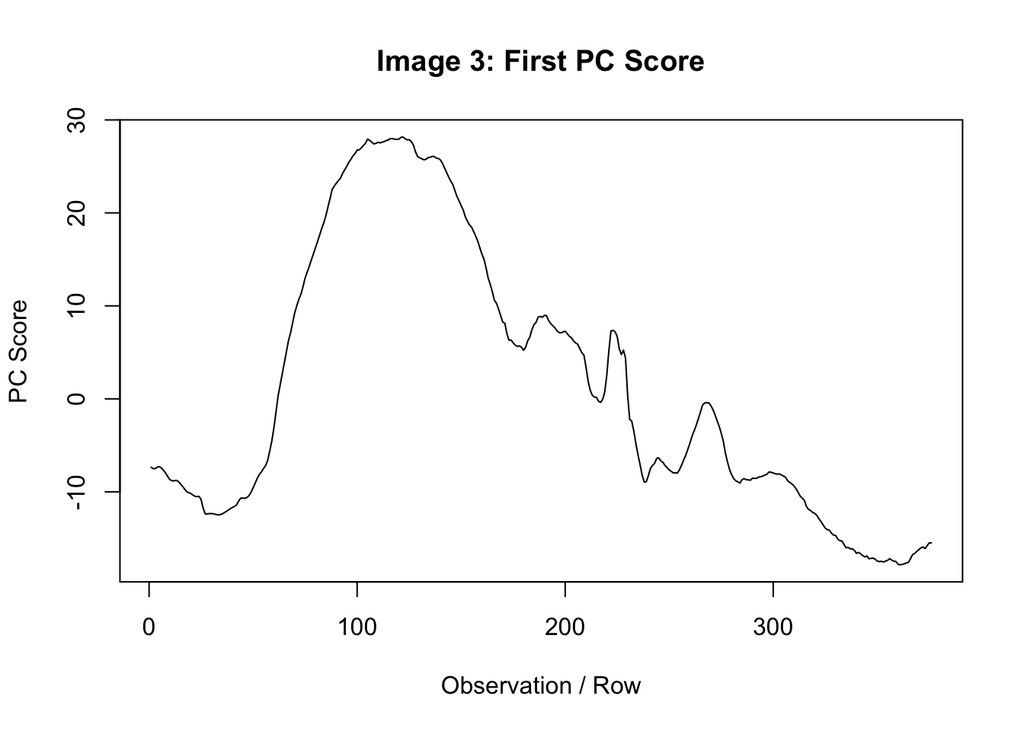

```r
plot(
  z1_3,
  type = "l",
  main = "Image 3: First PC Score",
  xlab = "Observation / Row",
  ylab = "PC Score"
)
```

## Analysis

The first eigenvector shows that the contribution of the image columns is not uniform. Some regions have larger negative loadings than others. The first PC score also changes smoothly across the rows. So the dominant image pattern varies systematically across the different vertical regions of the image.

k=10 might be a good approximation for image 3. The first few ranks are really blurry but by rank 10, the major features of the image are recognizable. The error plot also shows the largest reduction in reconstruction error occurs at small values of k.

## Image 4

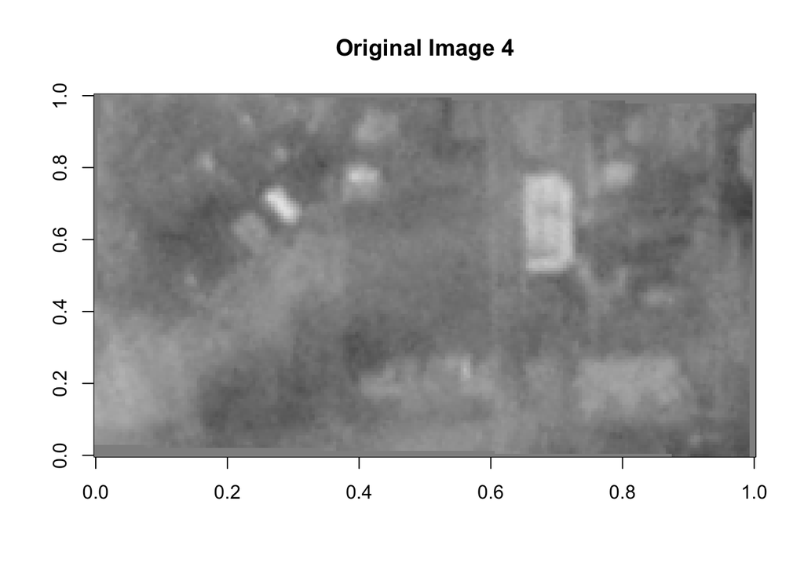

```r
x4 <- read_csv("image4.csv")
x4 <- data.matrix(x4)

image(
  x4,
  col = gray.colors(256),
  main = "Original Image 4"
)
```

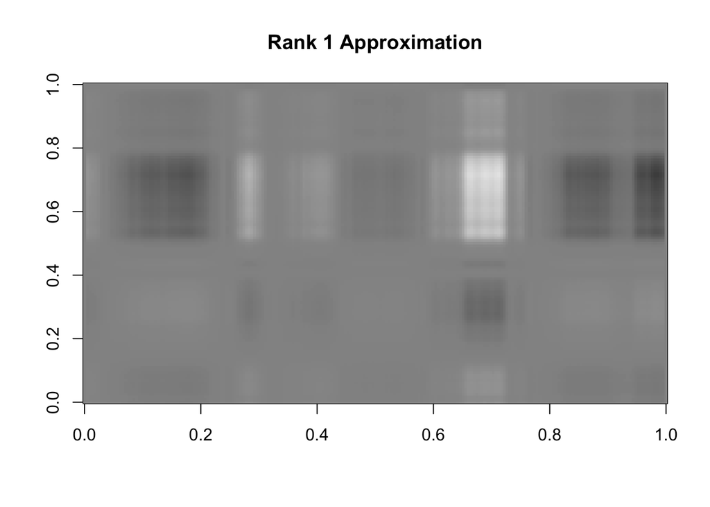

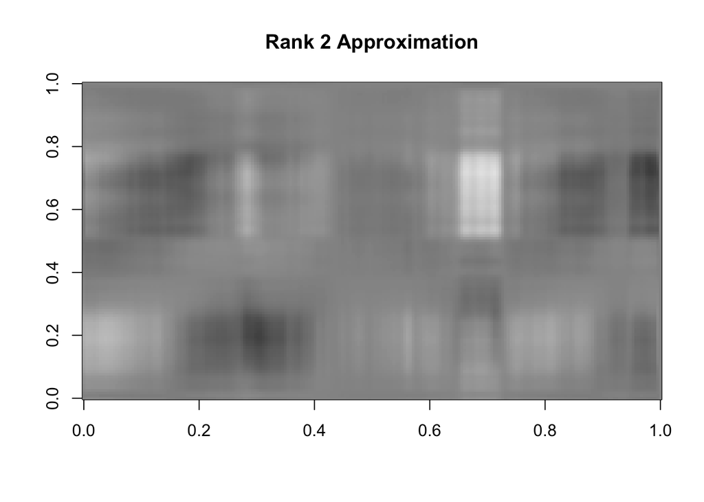

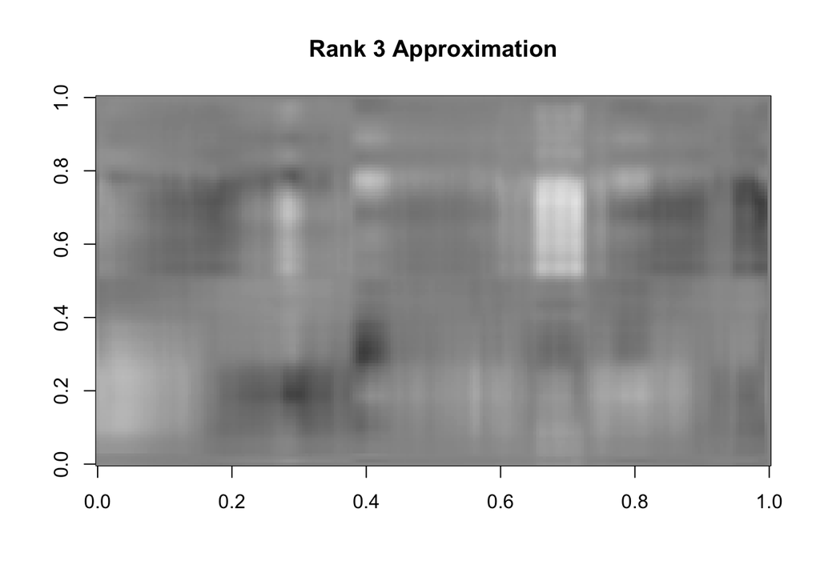

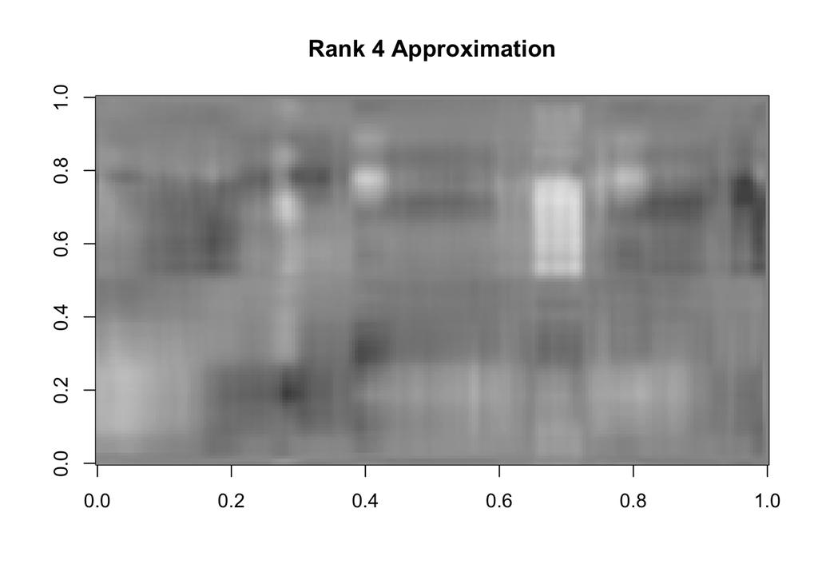

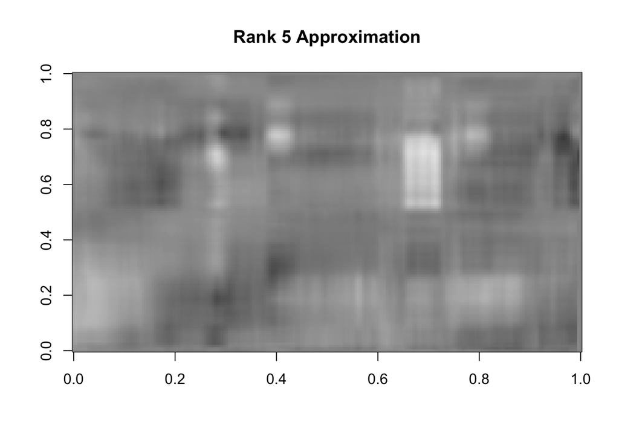

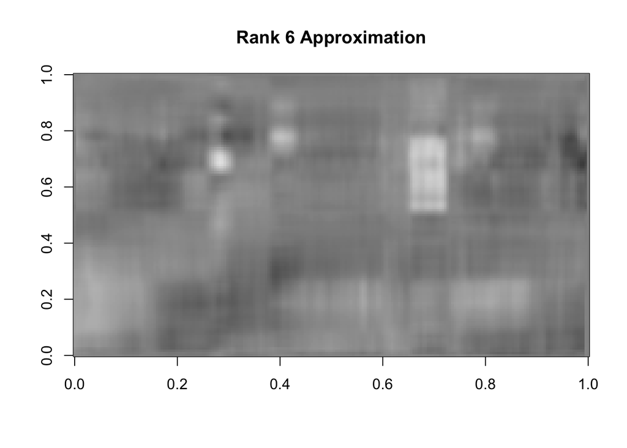

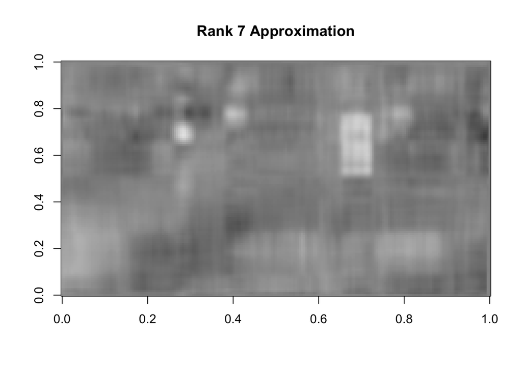

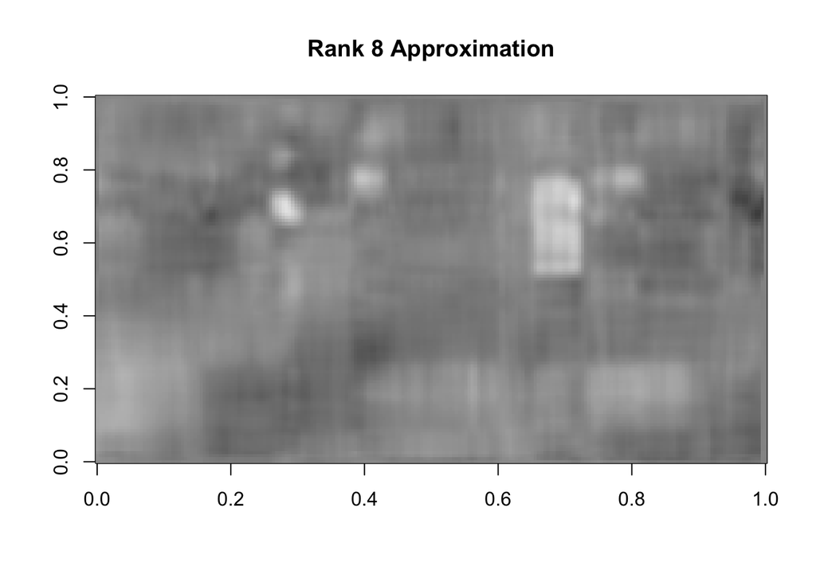

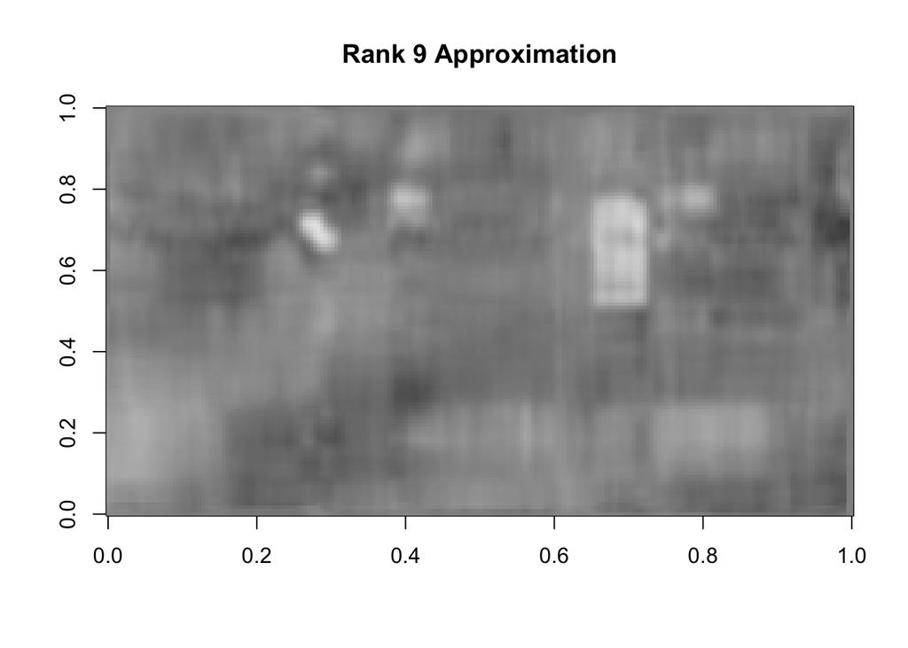

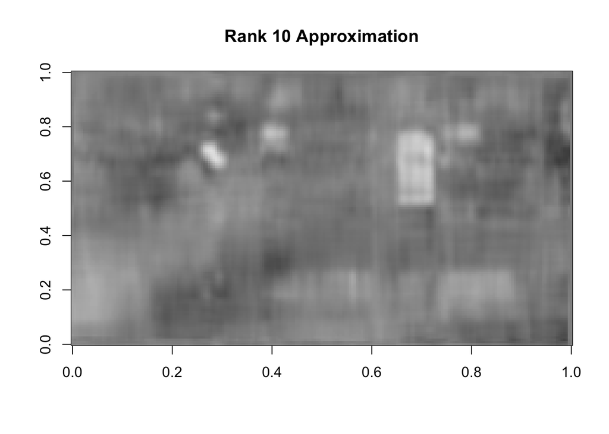

```r
for (k in 1:10) {
  result <- pca_rank_k_approx(x4, k)

  image(
    result$approx,
    col = gray.colors(256),
    main = paste("Rank", k, "Approximation")
  )
}
```

### Error plot

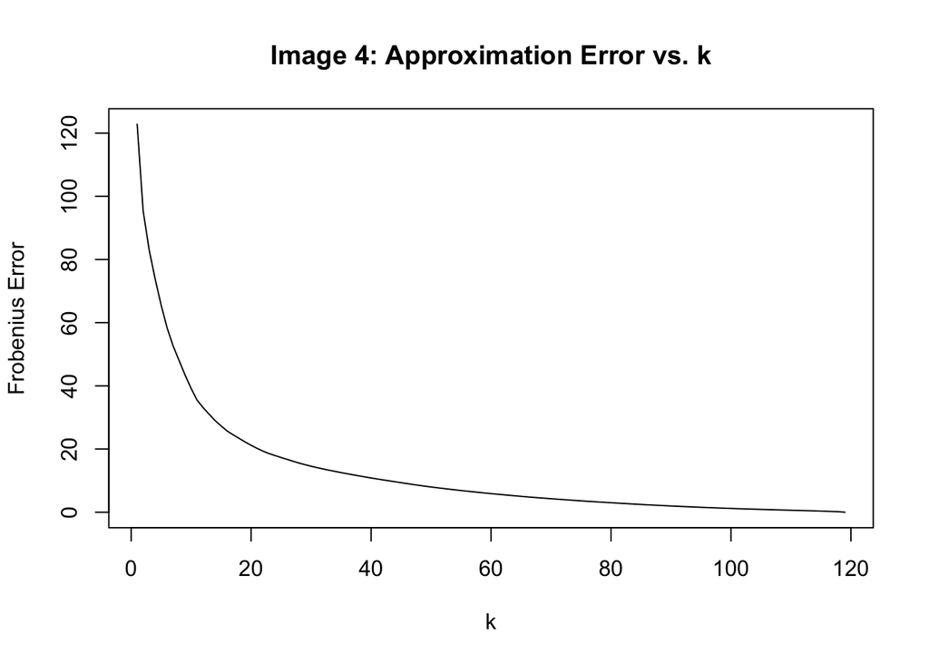

```r
p4 <- ncol(x4)
errors4 <- numeric(p4)

for (k in 1:p4) {
  result <- pca_rank_k_approx(x4, k)
  errors4[k] <- result$error
}

plot(
  1:p4,
  errors4,
  type = "l",
  xlab = "k",
  ylab = "Frobenius Error",
  main = "Image 4: Approximation Error vs. k"
)
```

### first eigenvector and PC score

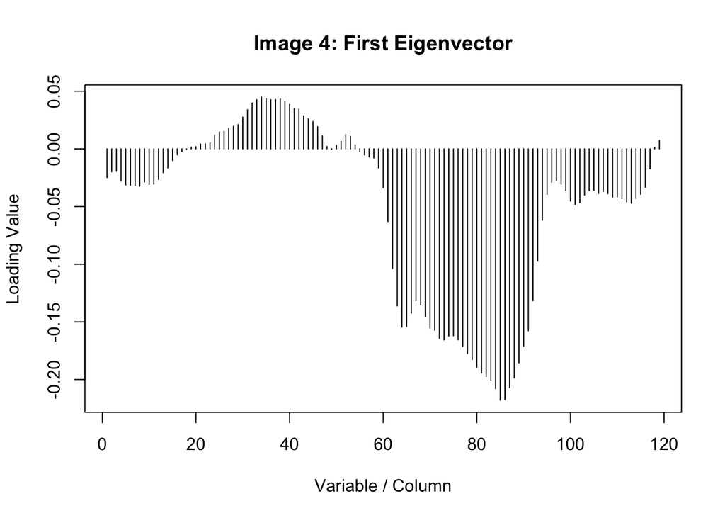

```r
pca4 <- prcomp(x4,
  center = FALSE,
  scale. = FALSE
)

u1_4 <- pca4$rotation[, 1]
z1_4 <- pca4$x[, 1]

plot(
  u1_4,
  type = "h",
  main = "Image 4: First Eigenvector",
  xlab = "Variable / Column",
  ylab = "Loading Value"
)
```

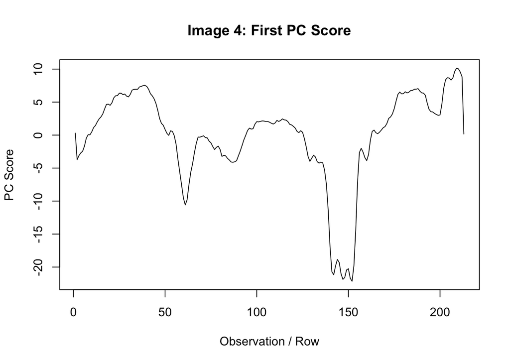

```r
plot(
  z1_4,
  type = "l",
  main = "Image 4: First PC Score",
  xlab = "Observation / Row",
  ylab = "PC Score"
)
```

## Analysis

The first eigenvector varies across the columns, with the largest negative loadings occurring approximately between columns 60 and 90. This suggests that this region contributes particularly strongly to the dominant variation captured by the first principal component. The first PC scores also vary systematically across the rows, with a particularly large negative region around rows 140–155. This indicates that the dominant pattern represented by PC1 is especially pronounced in that portion of the image.

I think k=10 also provides a good approximation for Image 4 because, at this rank, much of the major structure of the original image has been recovered. The error plot shows a rapid decrease at small values of k, followed by progressively smaller improvements as more components are added.